# Lab 03 - Nobel laureates

Max Asmar

## Introduction

In January 2017, Buzzfeed published an article on why Nobel laureates show immigration is so important for American science. You can read the article [here](https://www.buzzfeednews.com/article/peteraldhous/immigration-and-science). In the article they show that while most living Nobel laureates in the sciences are based in the US, many of them were born in other countries. This is one reason why scientific leaders say that immigration is vital for progress.

In this lab we will work with the data from this article to recreate some of their visualizations as well as explore new questions.

**Estimated time:** 90-120 minutes

## Learning Goals

By the end of this lab, you will be able to:

- Replicate published data visualizations
- Use `mutate()` with `if_else()` to create new variables
- Filter data based on multiple conditions
- Create faceted bar plots
- Create stacked/segmented bar plots
- Interpret visualizations in context of real-world questions

## Prerequisites

Before you begin, make sure you have:

- ✅ Completed Labs 01 and 02
- ✅ Read the Buzzfeed article: [*These Nobel Prize Winners Show Why Immigration Is So Important For American Science*](https://www.buzzfeednews.com/article/peteraldhous/immigration-and-science)
- ✅ Watched lectures on data wrangling and visualization
- ✅ Forked the lab-instructions repository

**Important:** Read the Buzzfeed article before starting this lab! You’ll be replicating their analysis, so familiarity with their findings is crucial.

## Understanding Merge Conflicts

As you work with Git and GitHub, you may occasionally encounter **merge conflicts**. While less common when working independently, it’s important to understand what they are.

**What causes a merge conflict?**

A merge conflict occurs when:

- You make changes to your local files
- Someone else (or you on another computer) makes different changes to the same part of the same file on GitHub
- Git can’t automatically determine which changes to keep

**What does a merge conflict look like?**

Git puts conflict markers in your code:

```
<<<<<<< HEAD
Your changes are here
=======
Their changes are here
>>>>>>> hash123abc
```

**How to resolve a merge conflict:**

Step 1. Edit the file to keep the changes you want

Step 2. Delete the `<<<`, `===`, and `>>>` markers

step 3. Save the file

Step 4. Stage, commit, and push

**Best practices to avoid merge conflicts:**

- Always **pull** before you start working
- **Commit and push** frequently
- If you do get a conflict, resolve it immediately before continuing work
- When in doubt, ask for help!

# Getting Started

Navigate to your forked `lab-instructions` repository in JupyterHub, open the `Lab03` folder, and open the R Markdown document `lab-03.Rmd`.

## Verify Your Setup

Before proceeding:

Step 1. Open `lab-03.Rmd` in RStudio

Step 2. Check that the Git pane shows YOUR username (not the course organization)

Step 3. Click **Knit** to make sure the document compiles

## Packages

We’ll use the **tidyverse** package for much of the data wrangling. This package is already installed for you. You can load it by running the following in your Console:

```r
library(tidyverse)
```

## Data

The dataset for this assignment can be found as a CSV (comma separated values) file in the `data` folder of your repository. You can read it in using the following.

```r
nobel <- read_csv("data/nobel.csv")
```

The variable descriptions are as follows:

- `id`: ID number
- `firstname`: First name of laureate
- `surname`: Surname
- `year`: Year prize won
- `category`: Category of prize
- `affiliation`: Affiliation of laureate
- `city`: City of laureate in prize year
- `country`: Country of laureate in prize year
- `born_date`: Birth date of laureate
- `died_date`: Death date of laureate
- `gender`: Gender of laureate
- `born_city`: City where laureate was born
- `born_country`: Country where laureate was born
- `born_country_code`: Code of country where laureate was born
- `died_city`: City where laureate died
- `died_country`: Country where laureate died
- `died_country_code`: Code of country where laureate died
- `overall_motivation`: Overall motivation for recognition
- `share`: Number of other winners award is shared with
- `motivation`: Motivation for recognition

In a few cases the name of the city/country changed after laureate was given (e.g. in 1975 Bosnia and Herzegovina was called the Socialist Federative Republic of Yugoslavia). In these cases the variables below reflect a different name than their counterparts without the suffix `_original`.

- `born_country_original`: Original country where laureate was born
- `born_city_original`: Original city where laureate was born
- `died_country_original`: Original country where laureate died
- `died_city_original`: Original city where laureate died
- `city_original`: Original city where laureate lived at the time of winning the award
- `country_original`: Original country where laureate lived at the time of winning the award

**✓ Checkpoint:** Run `glimpse(nobel)` in your Console to verify the data loaded correctly. You should see 935 observations and 26 variables.

# Warm Up

Before diving into the exercises, let’s get familiar with the data.

**Question 1:** How many observations and how many variables are in the dataset? Use inline code in your answer.

**Hint:** Use backtick r nrow(nobel) backtick for rows and backtick r ncol(nobel) backtick for columns in your narrative text.

**Your answer:** There are 935 observations and 26 variables in the dataset.

**Question 2:** Run `View(nobel)` in your Console. What does each row represent?

**Your answer:** Each row/observation represents a Nobel Laureate winner and his/her information such as name, year, category, city, etc. I did this by running `View(nobel)` in the console.

**Question 3:** Look at the data. What categories of Nobel prizes are included in this dataset?

**Hint:** Run `count(nobel, category)` in your Console.

**Your answer:**

In this dataset the categories are Chemistry, Economics, Literature, Medicine, Peace, and Physics. I did this by running `count(nobel, category)` in the Console.

🧶 ✅ ⬆️ **Knit, commit with message “Completed warm up”, and push your changes.**

# Exercises

## Exercise 1

How many observations and how many variables are in the dataset? Use inline code to answer this question. What does each row represent?

**Write your answer using inline code:**

The nobel dataset has 935 observations and 26 variables. Each row represents a set of information about a Nobel Laureate winner and his/her information such as name, year, category, city, etc .

There are some observations in this dataset that we will exclude from our analysis to match the Buzzfeed results.

## Exercise 2

Create a new data frame called `nobel_living` that filters for:

- laureates for whom `country` is available (not NA)
- laureates who are people as opposed to organizations (organizations are denoted with `"org"` as their `gender`)
- laureates who are still alive (their `died_date` is `NA`)

**Fill in the blanks below:**

```r
# Remember to change eval=FALSE to eval=TRUE!
nobel_living <- nobel %>%
  filter(
    !is.na(country),
    gender != "org",
    is.na(died_date)
  )
```

**Verify your filtering:** Confirm that once you have filtered for these characteristics you are left with a data frame with 228 observations. Use inline code to check: `nrow(nobel_living)`

**Your verification:** After filtering, nobel_living has 228 observations.

🧶 ✅ ⬆️ **Knit, commit with message “Completed Exercises 1-2”, and push your changes.**

## Most Living Nobel Laureates Were Based in the US When They Won Their Prizes

… says the Buzzfeed article. Let’s see if that’s true.

First, we’ll create a new variable to identify whether the laureate was in the US when they won their prize. We’ll use the `mutate()` function for this. The following pipeline mutates the `nobel_living` data frame by adding a new variable called `country_us`. We use an if statement to create this variable.

The `if_else()` function tests a condition. If TRUE, it returns the first value (“USA”); if FALSE, it returns the second value (“Other”).

```r
nobel_living <- nobel_living %>%
  mutate(
    country_us = if_else(country == "USA", "USA", "Other")
  )
```

**What this code does:**

- If `country` equals `"USA"`, set `country_us` to `"USA"`
- Otherwise, set `country_us` to `"Other"`

Next, we will limit our analysis to only the following categories: Physics, Medicine, Chemistry, and Economics.

```r
nobel_living_science  <- nobel_living %>%
  filter(category %in% c("Physics", "Medicine", "Chemistry", "Economics"))
```

**Important:** Make sure you run both code chunks above! You’ll need the `nobel_living_science` data frame for the next exercise.

## Exercise 3

Create a faceted bar plot visualizing the relationship between the category of prize and whether the laureate was in the US when they won the Nobel prize. Interpret your visualization, and say a few words about whether the Buzzfeed headline is supported by the data.

**Requirements:**

- Your visualization should be faceted by category
- For each facet you should have two bars, one for winners in the US and one for Other
- Flip the coordinates so the bars are horizontal, not vertical

**Build your visualization:**

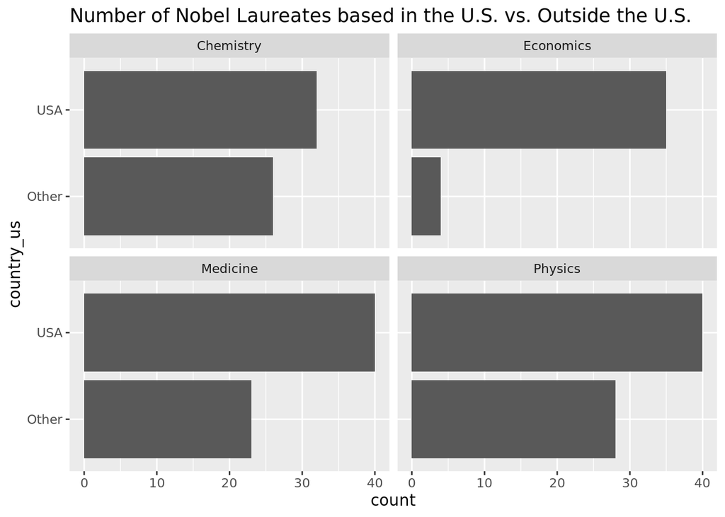

```r
# Remember to change eval=FALSE to eval=TRUE!
ggplot(data = nobel_living_science, aes(x = country_us)) +
  geom_bar() +
  coord_flip() +
  facet_wrap(~category) +
  ggtitle("Number of Nobel Laureates based in the U.S. vs. Outside the U.S.")
```

**Hints:**

- Put `country_us` on the x-axis (or y-axis before flipping)
- Use `facet_wrap(~category)`
- `coord_flip()` makes bars horizontal

**Interpretation:** Does the Buzzfeed headline (“Most living Nobel laureates were based in the US when they won their prizes”) appear to be supported by the data? Consider all four scientific categories.

**Your answer:**

I think that the Buzzfeed headline is supported by the data because in all 4 displines (Chemistry, Economics, Medicine, Physics) over half of the Nobel Laureates were based in the United States. This disparity is most clear in Economics, where the number of Nobel Laureates based in the U.S. is over 6 times the number of Nobel Laureates based outside. The discipline with the highest proportion of laureates not based in the US out of the 4 disciplines is Chemistry. I determined this by analyzing the bar charts for each discipline plotting the number of laureates based in the US or outside.

🧶 ✅ ⬆️ **Knit, commit with message “Completed Exercise 3”, and push your changes.**

## But of Those US-Based Nobel Laureates, Many Were Born in Other Countries

Now let’s investigate where the US-based laureates were actually born.

## Exercise 4

Create a new variable called `born_country_us` that has the value `"USA"` if the laureate is born in the US, and `"Other"` otherwise. How many of the winners are born in the US?

**Hint:** This is very similar to how we created `country_us` earlier. You can adapt that code!

```r
# Remember to change eval=FALSE to eval=TRUE!
nobel_living_science <- nobel_living_science %>%
  mutate(
    born_country_us = if_else(born_country == "USA", "USA", "Other")
  )
```

**Now count how many laureates were born in the US:**

```r
# Remember to change eval=FALSE to eval=TRUE!
nobel_living_science %>%
  count(born_country_us)
```

```
## # A tibble: 2 × 2
##   born_country_us     n
##   <chr>           <int>
## 1 Other             123
## 2 USA               105
```

**How many laureates were born in the US?** 105 laureates were born in the US

**How many were born in other countries?** 123 laureates were born outside the US.

## Exercise 5

Add a second variable to your visualization from Exercise 3 based on whether the laureate was born in the US or not. Based on your visualization, do the data appear to support Buzzfeed’s claim? Explain your reasoning in 1-2 sentences.

**Requirements:**

- Your final visualization should contain a facet for each category
- Within each facet, there should be a bar for whether the laureate won the award in the US or not
- Each bar should have segments for whether the laureate was born in the US or not

**Build your stacked bar chart:**

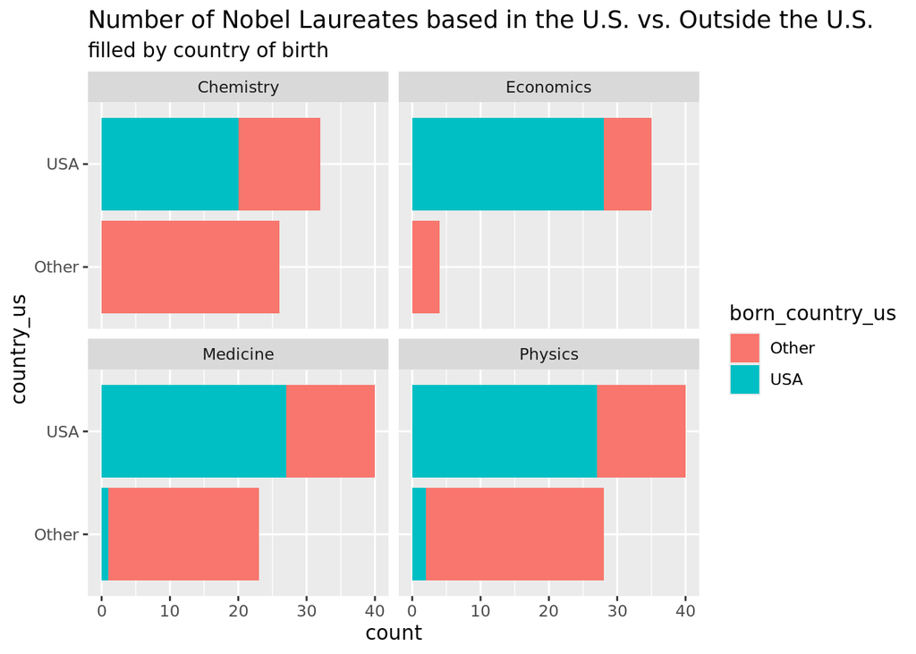

```r
# Remember to change eval=FALSE to eval=TRUE!
ggplot(data = nobel_living_science,
       aes(x = country_us, fill = born_country_us)) +
  geom_bar() +
  coord_flip() +
  facet_wrap(~category) +
  labs(
    title = "Number of Nobel Laureates based in the U.S. vs. Outside the U.S.",
    subtitle = "filled by country of birth"
  )
```

**Hints:**

- Use `fill = born_country_us` to color bars by birth country
- The rest is similar to Exercise 3

**Interpretation:** Based on your visualization, do the data appear to support Buzzfeed’s claim that many US-based laureates were born in other countries?

**Your answer: Based on my visualization, I think that the data supports the claim that many US-based laureates were born in other countries, but it depends on what “many” means. Looking at the visualization, I speculate that around 30% of US-based laureates were born in other countries for most disciplines out of chemistry, economics, medicine, and physics. However, a great majority of US-based economics laureates were US born. I estimate that around 20% of US-based economics laureates were foreign-born.**

🧶 ✅ ⬆️ **Knit, commit with message “Completed Exercises 4-5”, and push your changes.**

## Here’s Where Those Immigrant Nobelists Were Born

Note that your results won’t exactly match the Buzzfeed article. The data has been updated since the article was published.

## Exercise 6

In a single pipeline, filter for laureates who won their prize in the US, but were born outside of the US, and then create a frequency table (with the `count()` function) for their birth country (`born_country`) and arrange the resulting data frame in descending order of number of observations for each country. Which country is the most common?

**Build your pipeline:**

```r
# Remember to change eval=FALSE to eval=TRUE!
nobel_living_science %>%
  filter(
    country_us == "USA",
    born_country_us == "Other"
  ) %>%
  count(born_country) %>%
  arrange(desc(n))
```

```
## # A tibble: 21 × 2
##    born_country       n
##    <chr>          <int>
##  1 Germany            7
##  2 United Kingdom     7
##  3 China              5
##  4 Canada             4
##  5 Japan              3
##  6 Australia          2
##  7 Israel             2
##  8 Norway             2
##  9 Austria            1
## 10 Finland            1
## # ℹ 11 more rows
```

**Which country (outside the US) has produced the most Nobel laureates who won while based in the US?**

**How many laureates from this country won while based in the US?**

🧶 ✅ ⬆️ **Knit, commit with message “Completed Exercise 6”, and push your changes.**

## Common Errors and Troubleshooting

**Data wrangling errors:**

- **Error: “object ‘nobel_living’ not found”** → Make sure you ran the code chunk that creates this data frame
- **Error: “object ‘nobel_living_science’ not found”** → Make sure you ran the code chunk that creates this filtered data frame
- **Filter not working as expected** → Check your logic: `==` for equals, `!=` for not equals, `is.na()` for missing values
- **`if_else()` not working** → Make sure the condition comes first, then the TRUE value, then the FALSE value

**Visualization errors:**

- **Bars not showing correctly** → Check that you’re using the right variable for x-axis and fill
- **Facets not appearing** → Make sure you’re using `facet_wrap(~category)` with the tilde
- **Bars are vertical instead of horizontal** → Add `coord_flip()` to your plot
- **Colors not showing segments** → Use `fill = born_country_us` inside `aes()`, not `color`

**General issues:**

- **Code chunk not running** → Make sure you changed `eval=FALSE` to `eval=TRUE`
- **Inline code not working** → Use backticks with r
- **Changes not on GitHub** → Remember to commit AND push

**Key insight:** The Buzzfeed article’s claims are supported by the data - while most living Nobel laureates in the sciences were based in the US when they won their prizes, a significant proportion of those US-based laureates were actually born in other countries. This demonstrates the important role of immigration in American scientific achievement.

## Optional: Interested in How Buzzfeed Made Their Visualizations?

The plots in the Buzzfeed article are called waffle plots. You can find the code used for making these plots in Buzzfeed’s GitHub repo (yes, they have one!) [here](https://buzzfeednews.github.io/2017-01-immigration-and-science/).

You’re not expected to recreate them as part of your assignment, but you’re welcome to explore for fun!

**To submit to Canvas:**

Step 1. In RStudio, click the **Knit** dropdown menu (next to the Knit button)

Step 2. Select **Knit to tufte_handout** to generate a PDF

Step 3. Download the PDF file from the Files pane

Step 4. Upload the PDF to Canvas

**✓ Final Checkpoint:** Visit your GitHub repo one more time to confirm all your work is there. We will grade what we see in your repo on GitHub!